# TUMI Microbiome/Data Science Weekly Meeting - Introduction to ggplot2

Maureen Carey

6/1/2021

This tutorial is an introduction to make figures programmatically in R with ggplot2 and uses data from Carey et al.[^1]

# Prep computational environment

Set path. This will change on your computer - indicate the folder where you saved the data.

```r
knitr::opts_chunk$set(echo = TRUE)

path = "/path/to/data/"

knitr::opts_knit$set(root.dir = path)
```

Load packages.

```r
library(tidyverse) #dplyr, tidyr
load("for_ggplot2_tutorial.RData")
```

Let’s say you want to make a publication-quality figure like this:

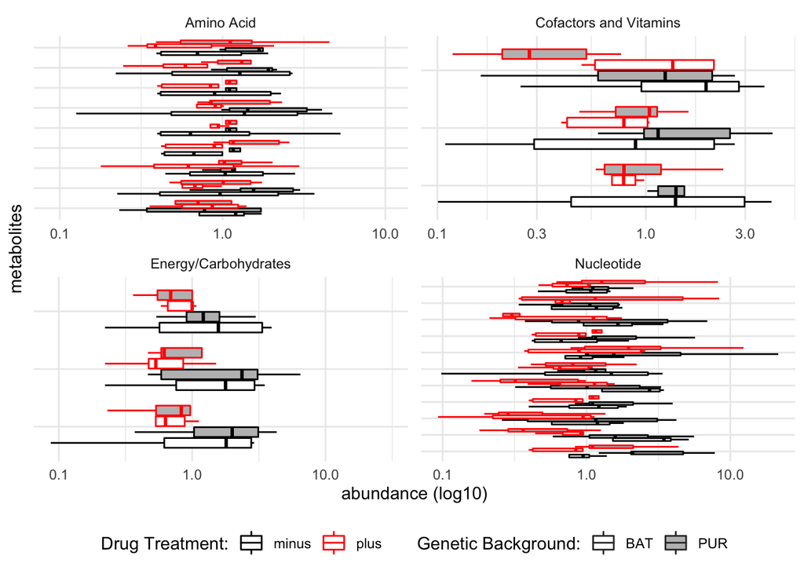

The biggest strength of making figures programmatically (as opposed to Excel or Prism, or other approaches that don’t use code) is that your figures are 100% reproducible and customizable and all errors are traceable. Making figures in Excel or Prism may be easier to start, but there is no documentation (i.e. code) of what you did.

`ggplot2`, the package used here, is just one way to do it and my personal favorite. Strengths of `ggplot2` specifically are that its relatively easy to make publication quality figures and many application-focused packages provide even-easier-to-use wrappers for ggplot plotting.

My favorite feature of `ggplot2` is how you can layer on new information or plotting approaches. For example, in the plot above, we first specified what data would be used and the x- and y-axes here:

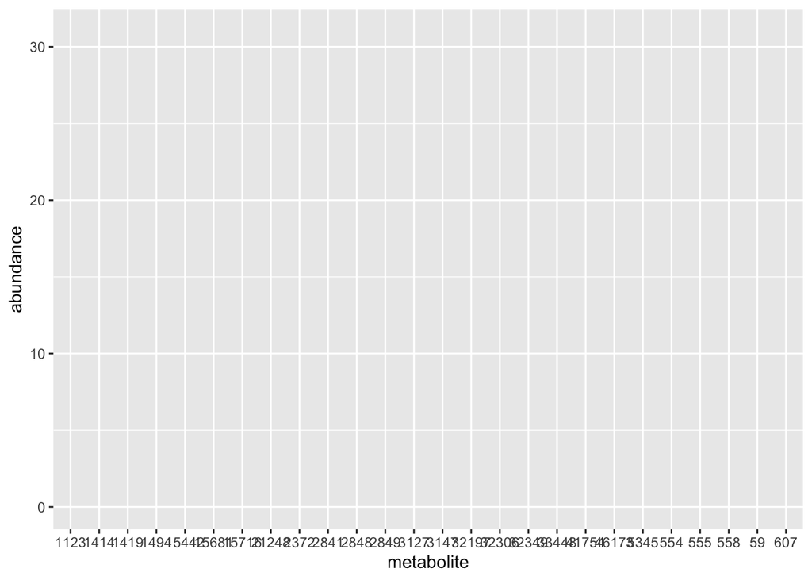

```r
ggplot(data = plot_these,
           aes(x = metabolite, y = abundance, color = drug_treatment, fill = genetic_background))
```

Next, we told the program what type of plot to make (boxplot) so it plotted the data (specified in the first step) using this approach:

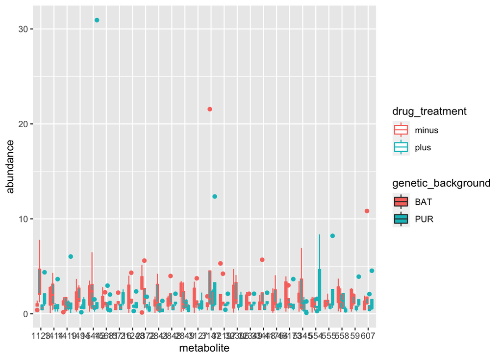

```r
ggplot(data = plot_these,
           aes(x = metabolite, y = abundance, color = drug_treatment, fill = genetic_background)) +
  geom_boxplot()
```

We can also hide all outliers on the plot with this:

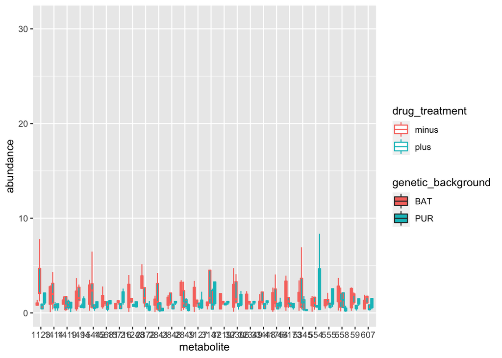

```r
ggplot(data = plot_these,
           aes(x = metabolite, y = abundance, color = drug_treatment, fill = genetic_background)) +
  geom_boxplot(outlier.shape = NA)
```

However, we are actually interested in separating each type of metabolite into groups, like this:

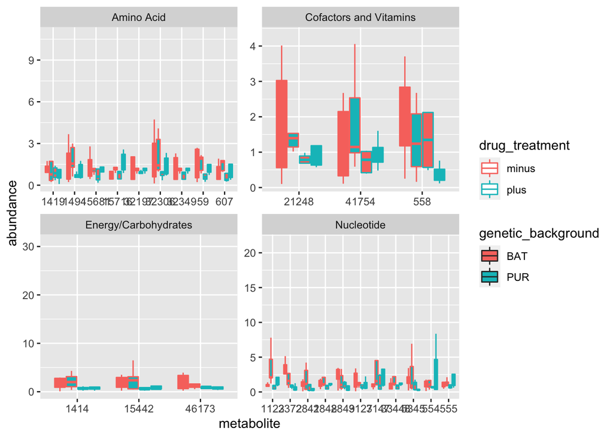

```r
ggplot(data = plot_these,
           aes(x = metabolite, y = abundance, color = drug_treatment, fill = genetic_background)) +
  geom_boxplot(outlier.shape = NA) +
  facet_wrap(~group_use, scales = "free")
```

But these colors are rather uninterpretable, so let’s change them:

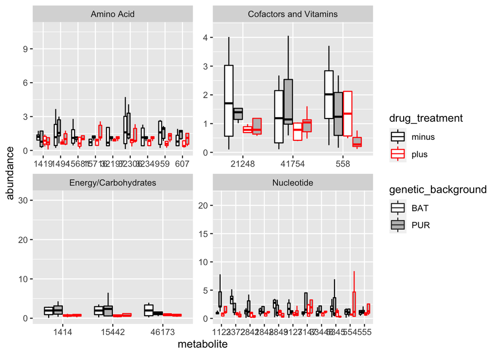

```r
ggplot(data = plot_these,
           aes(x = metabolite, y = abundance, color = drug_treatment, fill = genetic_background)) +
  geom_boxplot(outlier.shape = NA) +
  facet_wrap(~group_use, scales = "free") +
  scale_color_manual(values = c("black","red")) +
  scale_fill_manual(values = c("white","grey"))
```

I prefer the plot to be flipped, so we can do that here:

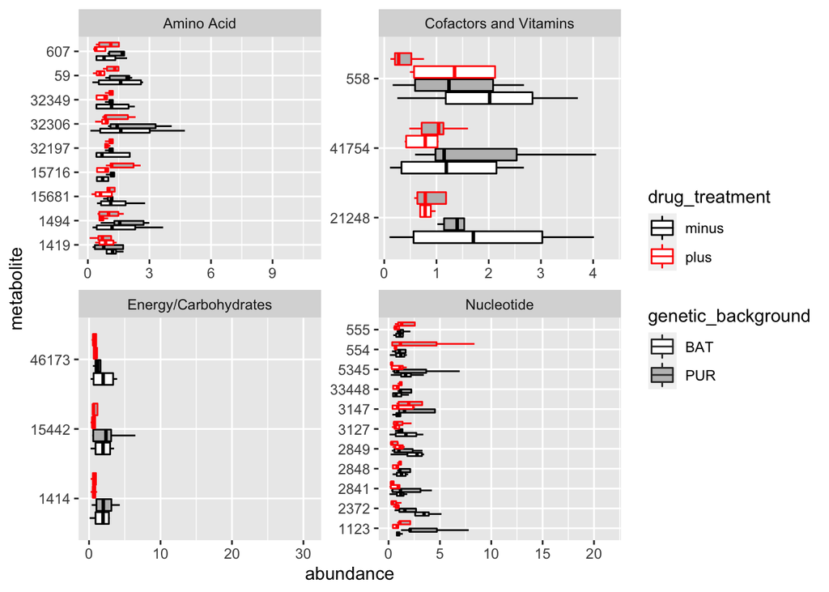

```r
ggplot(data = plot_these,
           aes(x = metabolite, y = abundance, color = drug_treatment, fill = genetic_background)) +
  geom_boxplot(outlier.shape = NA) +
  facet_wrap(~group_use, scales = "free") +
  scale_color_manual(values = c("black","red")) +
  scale_fill_manual(values = c("white","grey")) +
  coord_flip()
```

Let’s now remove the metabolite identifiers since they are not terribly useful:

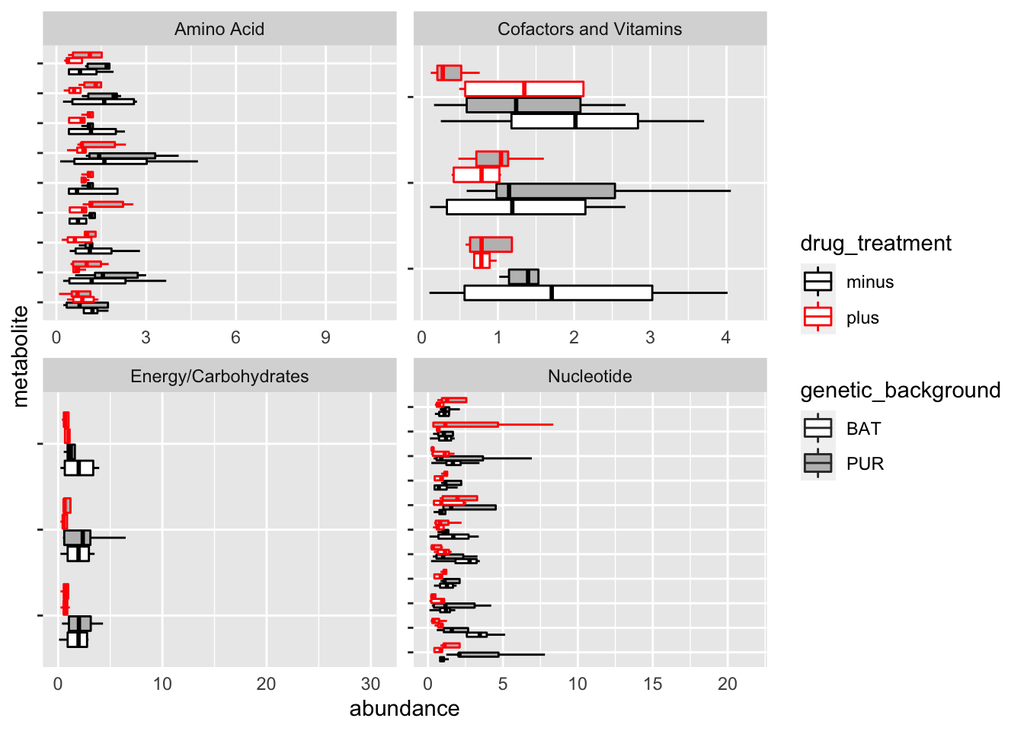

```r
ggplot(data = plot_these,
           aes(x = metabolite, y = abundance, color = drug_treatment, fill = genetic_background)) +
  geom_boxplot(outlier.shape = NA) +
  facet_wrap(~group_use, scales = "free") +
  scale_color_manual(values = c("black","red")) +
  scale_fill_manual(values = c("white","grey")) +
  coord_flip() +
  theme(axis.ticks.x = element_blank(),
        axis.text.y = element_blank())
```

Next, let’s change the scale of the ‘abundance’ axis to make it clearer:

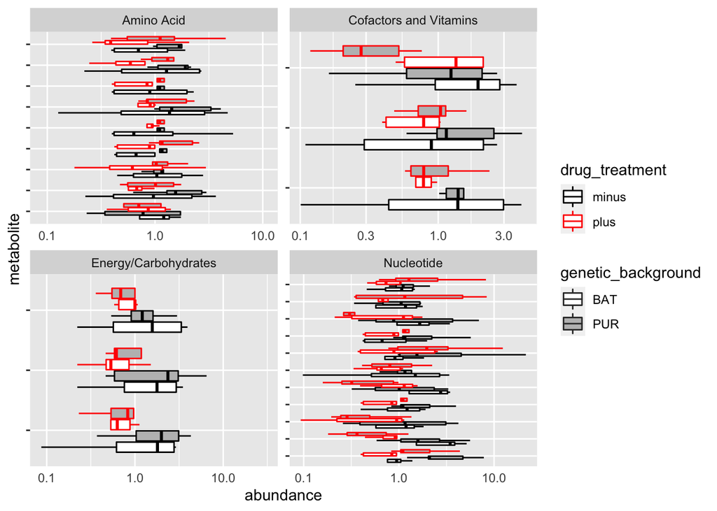

```r
ggplot(data = plot_these,
           aes(x = metabolite, y = abundance, color = drug_treatment, fill = genetic_background)) +
  geom_boxplot(outlier.shape = NA) +
  facet_wrap(~group_use, scales = "free") +
  scale_color_manual(values = c("black","red")) +
  scale_fill_manual(values = c("white","grey")) +
  coord_flip() +
  theme(axis.ticks.x = element_blank(),
        axis.text.y = element_blank()) +
  scale_y_log10()
```

Let’s now change the labels for the x- and y-axes:

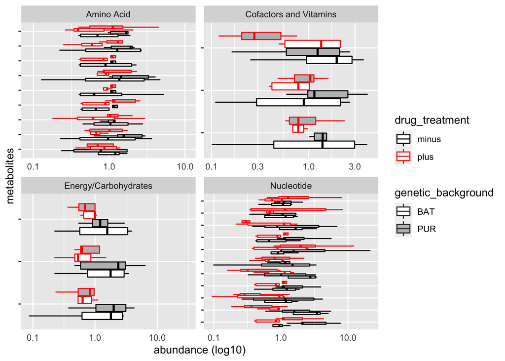

```r
ggplot(data = plot_these,
           aes(x = metabolite, y = abundance, color = drug_treatment, fill = genetic_background)) +
  geom_boxplot(outlier.shape = NA) +
  facet_wrap(~group_use, scales = "free") +
  scale_color_manual(values = c("black","red")) +
  scale_fill_manual(values = c("white","grey")) +
  coord_flip() +
  theme(axis.ticks.x = element_blank(),
        axis.text.y = element_blank()) +
  scale_y_log10() +
  ylab('abundance (log10)') + xlab('metabolites')
```

And change the location and capitalization on the legend:

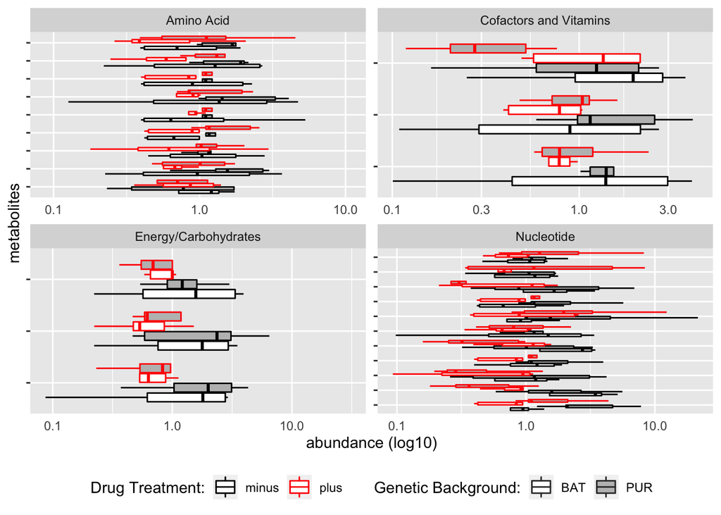

```r
ggplot(data = plot_these,
           aes(x = metabolite, y = abundance, color = drug_treatment, fill = genetic_background)) +
  geom_boxplot(outlier.shape = NA) +
  facet_wrap(~group_use, scales = "free") +
  scale_color_manual(values = c("black","red")) +
  scale_fill_manual(values = c("white","grey")) +
  coord_flip() +
  theme(axis.ticks.x = element_blank(),
        axis.text.y = element_blank(),
        legend.position = "bottom") +
  scale_y_log10() +
  ylab('abundance (log10)') + xlab('metabolites') +
  labs(fill = "Genetic Background:", color = "Drug Treatment:")
```

And lastly, let’s get rid of the grey background.

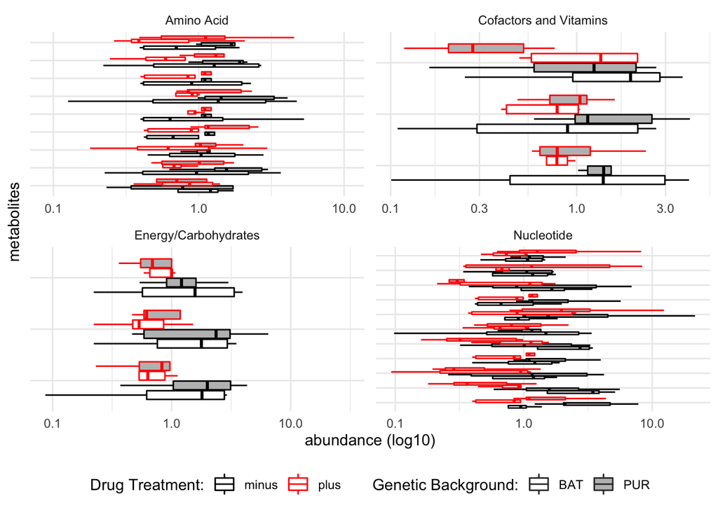

```r
ggplot(data = plot_these,
           aes(x = metabolite, y = abundance, color = drug_treatment, fill = genetic_background)) +
  geom_boxplot(outlier.shape = NA) +
  facet_wrap(~group_use, scales = "free") +
  scale_color_manual(values = c("black","red")) +
  scale_fill_manual(values = c("white","grey")) +
  coord_flip() +
  theme_minimal() +
  theme(axis.ticks = element_blank(),
        axis.text.y = element_blank(),
        legend.position = "bottom") +
  scale_y_log10() +
  ylab('abundance (log10)') + xlab('metabolites') +
  labs(fill = "Genetic Background:", color = "Drug Treatment:")
```

(Notice how we generally added each layer to the end of the code except for ‘theme_minimal’. That is because ‘theme_minimal’ will override our custom ‘theme’ layer where we hid the ticks and text on one axis.)